# Post Goals:

1. Introduction to nonparametric procedures on two population.
2. Sign Test
3. Wilcoxon Signed Rank Test
4. Wilcoxon-Mann-Whitney Rank Sum Test

# Introduction to nonparametric procedures on two population.

**The basics**

- Not all inference tests that compare two samples have populations drawn from normal distributions.
- In this post I will dive into a few nonparametric procedures that can be used when data is not normally distributed.
- The sign test (median test) allows us to perform a hypothesis test on a population median, and consider the number of events that fall below and above. We use this test in lieu of the t-test for a single population mean.
- The sign test can be used when the assumptions of normality fail a paired t-test, since the paired test is a hypothesis test on a single sample (the differences) between the two sample populations.
- Another more powerful test is the Wilcoxon signed rank test and can be used for making inferences on a single population median, or in a paired/dependent sampling scheme.
- The final test that will be discussed here is the Mann-Whitney U-test, which is the analogue of the two-sample t-test, although this test finds the difference in the median between two populations that are sampled independently from each other.
- The Mann-Whitney U-test is also called the Wilcoxon rank sum test and the Wilcoxon-Mann-Whitney test.

# Sign Test

**The Basics**

- Use this test if you are interested in deciding if the median of the population is different in a paired sampling scheme is 0 or not.
- Assumptions:
  - The difference comes from a random sample.
  - The difference is continous
- Hypothesis test:
  - Null Hypothesis. $H_o: \tilde{\mu_{D}} = 0 $
  - Alternative Hypothesis 2 sided: $H_a: \tilde{\mu_D} \neq 0 $
  - Alternative Hypothesis 1 sided lower tail: $H_a: \tilde{\mu_D} < 0 $
  - Alternative Hypothesis 1 sided upper tail: $H_a: \tilde{\mu_D} > 0 $
- R method: `binom.test(x, n, p=P0, alt=TYPE, conf.level=CL)`

# Example 1: cholesterol levels using Sign Test

- Is the median after treatment 0

```r
cholesterol <- read.csv('data/cholesterol.paired.csv')
attach(cholesterol)
cholesterol
```

A data.frame: 15 × 3

| subj <int> | before <int> | after <int> |
| --- | --- | --- |
| 1 | 265 | 258 |
| 2 | 240 | 234 |
| 3 | 258 | 245 |
| 4 | 295 | 286 |
| 5 | 251 | 239 |
| 6 | 245 | 235 |
| 7 | 287 | 280 |
| 8 | 314 | 301 |
| 9 | 260 | 248 |
| 10 | 279 | 268 |
| 11 | 283 | 264 |
| 12 | 240 | 228 |
| 13 | 238 | 234 |
| 14 | 225 | 216 |
| 15 | 247 | 237 |

## Calculations

```r
diff <- before - after
sum(diff > 0)
binom.test(x=15, n=15, alt='g')
```

15

```
	Exact binomial test

data:  15 and 15
number of successes = 15, number of trials = 15, p-value = 3.052e-05
alternative hypothesis: true probability of success is greater than 0.5
95 percent confidence interval:
 0.8189637 1.0000000
sample estimates:
probability of success
                     1
```

## Example 1 Result Reject $H_0$ The p value is less than the alpha level, the result suggest the differences are positive, cholesterol is down due to intervention

# Wilcoxon Signed Rank Test

**The Basics**

- Use the Wilcoxon Signed Rank Test on a paired sampling scheme or a single sample, but its similar to a paired t-test for data that is not normally distributed.
- The Wilcoxon signed rank test is a test for the population median, with the assumption that the differences have a symmetric distribution.
- Assumptions:
  - The differences comes from a random sample.
  - The differences is either numeric or ordinal
  - The differences is symmetric
- Hypothesis test:
  - Null Hypothesis. $H_o: \tilde{\mu_{D}} = 0 $
  - Alternative Hypothesis 2 sided: $H_a: \tilde{\mu_D} \neq 0 $
  - Alternative Hypothesis 1 sided lower tail: $H_a: \tilde{\mu_D} < 0 $
  - Alternative Hypothesis 1 sided upper tail: $H_a: \tilde{\mu_D} > 0 $
- R method: `wilcox.test(before, after, paired=TRUE, alt=TYPE, conf.level=CL)`

# Example 2: cholesterol levels using the Wilcox test

- Check if the difference between the paired sample is symmetric
- If yes, perform the test

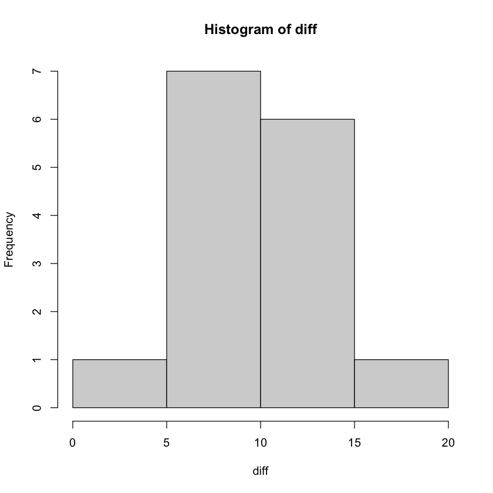

```r
# Check if difference is symmetric
hist(diff)
```

```r
wilcox.test(cholesterol$before,cholesterol$after,paired=TRUE,alt='g')
```

```
	Wilcoxon signed rank test with continuity correction

data:  cholesterol$before and cholesterol$after
V = 120, p-value = 0.0003561
alternative hypothesis: true location shift is greater than 0
```

## Example 2 Result Reject $H_0$ The p value is less than the alpha level, the result suggest the differences are positive, cholesterol is down due to intervention

# Wilcoxon-Mann-Whitney Rank Sum Test

**The Basics**

- Use this test when you have two independent samples whose data is not normally distributed.
- The Wilcoxon signed rank test is a test for the population median, with the assumption that the differences have a symmetric distribution.
- Assumptions:
  - Random sample with same variable from populations
  - The samples are independent form one another.
  - The data is either numeric or ordinal
  - The two populations curves have the same "shape".
- Hypothesis test:
  - Null Hypothesis. $H_o: \tilde{\mu_1} = \tilde{\mu_2} $
  - Alternative Hypothesis 2 sided: $H_a: \tilde{\mu_1} \neq \tilde{\mu_2} $
  - Alternative Hypothesis 1 sided lower tail: $H_a: \tilde{\mu_1} < \tilde{\mu_2} $
  - Alternative Hypothesis 1 sided upper tail: $H_a: \tilde{\mu_1} > \tilde{\mu_2} $
- R method: `wilcox.test(chol~group, alt='g')`

# Example 3: cholesterol levels using the Wilcoxon-Mann-Whitney Rank Sum Test

- This is a test that has two independent samples that either received treatment or did not
- Need to check that the two samples have the same "shape", will use a boxplot

```r
# Load Data
cholesterol_exp2 <- read.csv('data/cholesterol.csv')
```

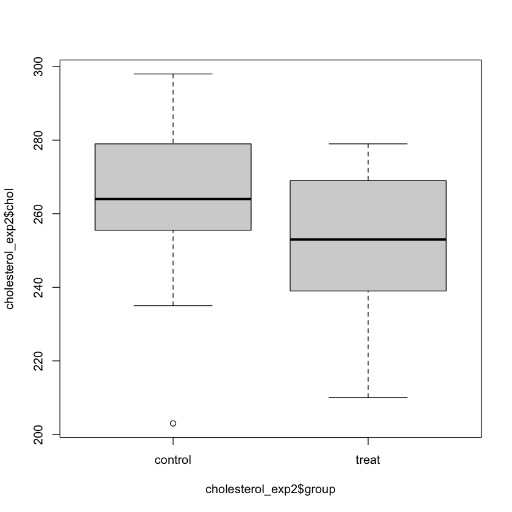

```r
# Box plot
boxplot(cholesterol_exp2$chol~cholesterol_exp2$group)
```

```r
# peform test
wilcox.test(cholesterol_exp2$chol~cholesterol_exp2$group, alt='g')
```

```
	Wilcoxon rank sum test with continuity correction

data:  cholesterol_exp2$chol by cholesterol_exp2$group
W = 148, p-value = 0.073
alternative hypothesis: true location shift is greater than 0
```

## Example 3 Result Accept $H_0$ The p value is greater than the alpha level, the result suggest the two groups are not different.